# 课堂练习

范琴

2019-06-05

```r
library(ggplot2)
ToothGrowth
```

```
##     len supp dose
## 1   4.2   VC  0.5
## 2  11.5   VC  0.5
## 3   7.3   VC  0.5
## 4   5.8   VC  0.5
## 5   6.4   VC  0.5
## 6  10.0   VC  0.5
## 7  11.2   VC  0.5
## 8  11.2   VC  0.5
## 9   5.2   VC  0.5
## 10  7.0   VC  0.5
## 11 16.5   VC  1.0
## 12 16.5   VC  1.0
## 13 15.2   VC  1.0
## 14 17.3   VC  1.0
```

[output cut: 46 more lines]

```r
head(ToothGrowth)
```

```
##    len supp dose
## 1  4.2   VC  0.5
## 2 11.5   VC  0.5
## 3  7.3   VC  0.5
## 4  5.8   VC  0.5
## 5  6.4   VC  0.5
## 6 10.0   VC  0.5
```

这是芽的生长

```r
library(ggplot2)
ToothGrowth
```

```
##     len supp dose
## 1   4.2   VC  0.5
## 2  11.5   VC  0.5
## 3   7.3   VC  0.5
## 4   5.8   VC  0.5
## 5   6.4   VC  0.5
## 6  10.0   VC  0.5
## 7  11.2   VC  0.5
## 8  11.2   VC  0.5
## 9   5.2   VC  0.5
## 10  7.0   VC  0.5
## 11 16.5   VC  1.0
## 12 16.5   VC  1.0
## 13 15.2   VC  1.0
## 14 17.3   VC  1.0
```

[output cut: 46 more lines]

```r
head(ToothGrowth)
```

```
##    len supp dose
## 1  4.2   VC  0.5
## 2 11.5   VC  0.5
## 3  7.3   VC  0.5
## 4  5.8   VC  0.5
## 5  6.4   VC  0.5
## 6 10.0   VC  0.5
```

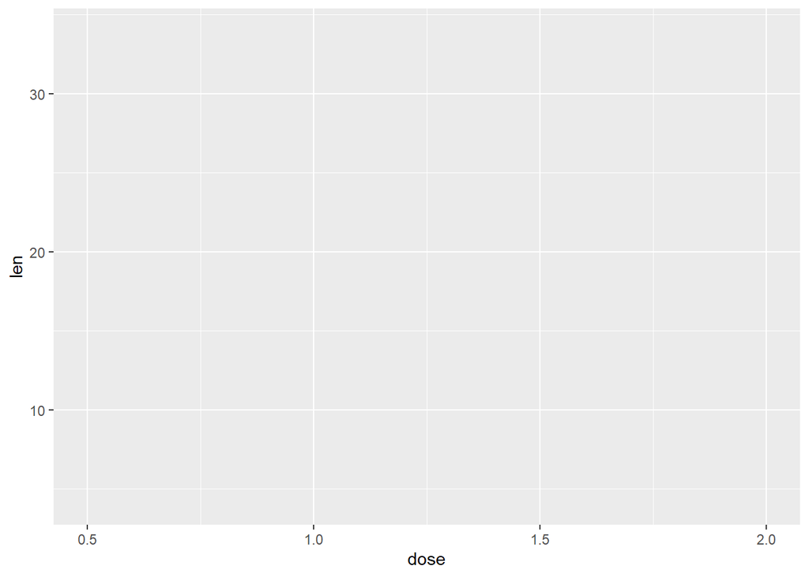

```r
g <-ggplot(ToothGrowth,aes(x=dose,y=len))
g
```

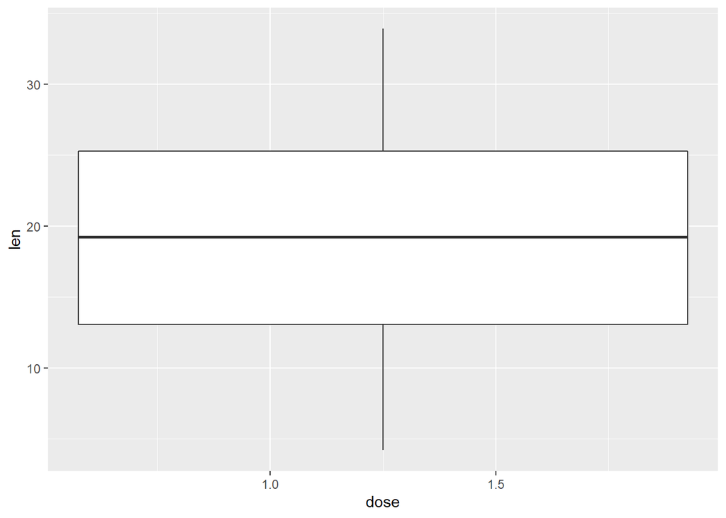

```r
g +geom_boxplot(aes(color=dose))
```

color是边际改变，fill是里面的改变即填充 fill=supp根据供应商分类

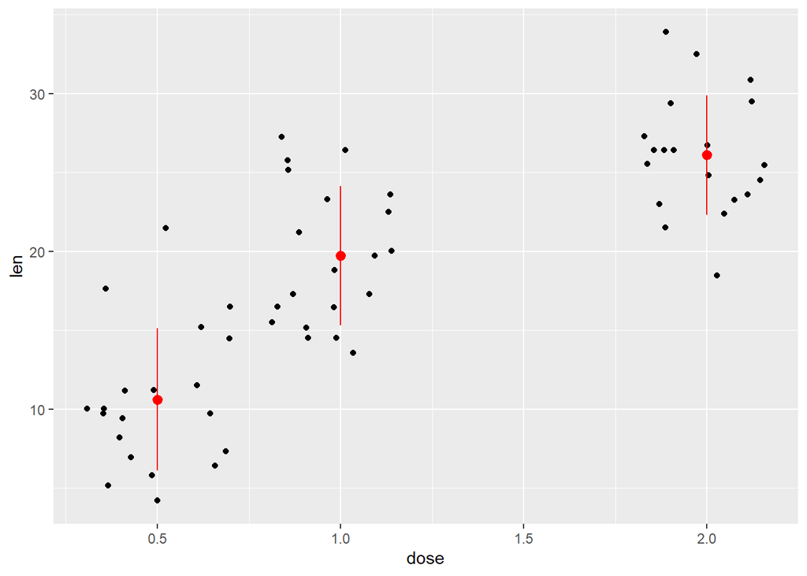

```r
library(ggplot2)
g + geom_jitter(position=position_jitter(0.2)) +
  stat_summary(fun.data="mean_sdl",  fun.args = list(mult=1),
               geom="pointrange", color = "red")
```

stack叠加 fun.data=“mean_sdl”计算中间值 dose计量，不同的计量有不同的颜色 factor分类，在灵魂里穿衣服 color 或者factor在身体上穿衣服 geom point(color=“red”)实际显示的内容 颜色会覆盖，ggplot(data,aes(x,y,color,fill)) 对数据求标准差，fun,是function,fun.data=“mean_sdl” position=position_jitter(0.2)位置的偏移

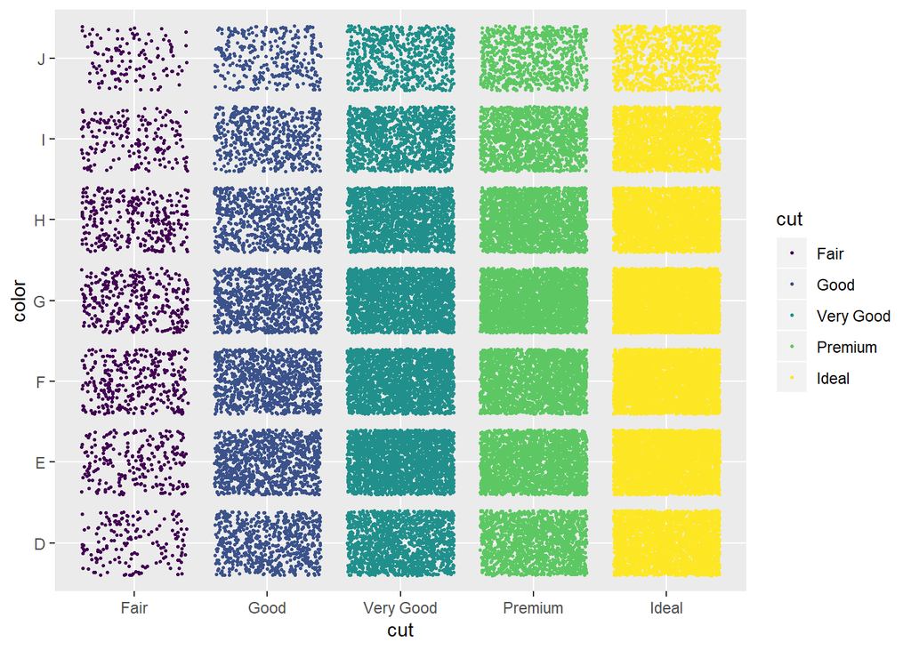

```r
library(ggplot2)
ggplot(diamonds, aes(cut, color)) +
  geom_jitter(aes(color = cut), size = 0.5)
```

```r
library(ggplot2)
df <- ToothGrowth
df$dose <- as.factor(df$dose)
head(df)
```

```
##    len supp dose
## 1  4.2   VC  0.5
## 2 11.5   VC  0.5
## 3  7.3   VC  0.5
## 4  5.8   VC  0.5
## 5  6.4   VC  0.5
## 6 10.0   VC  0.5
```

```r
data_summary <- function(data, varname, grps){
  require(plyr)
  summary_func <- function(x, col){
    c(mean = mean(x[[col]], na.rm=TRUE),
      sd = sd(x[[col]], na.rm=TRUE))
  }
  data_sum<-ddply(data, grps, .fun=summary_func, varname)
  data_sum <- rename(data_sum, c("mean" = varname))
 return(data_sum)
}
df2 <- data_summary(df, varname="len", grps= "dose")
# Convert dose to a factor variable
df2$dose=as.factor(df2$dose)
head(df2)
```

```
##   dose    len       sd
## 1  0.5 10.605 4.499763
## 2    1 19.735 4.415436
## 3    2 26.100 3.774150
```

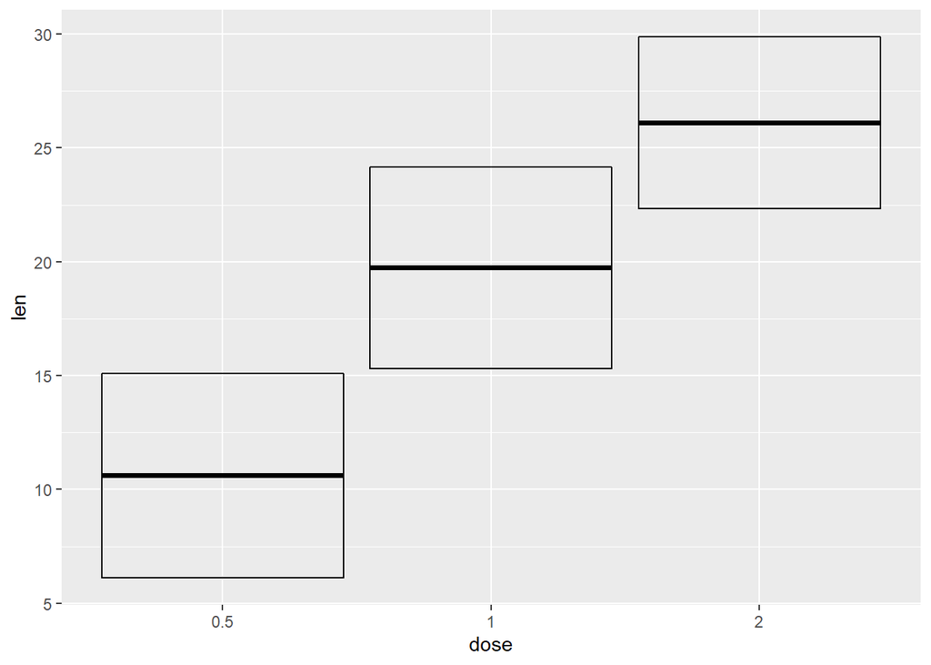

```r
f <- ggplot(df2, aes(x = dose, y = len,
                     ymin = len-sd, ymax = len+sd))
f+geom_crossbar()
```

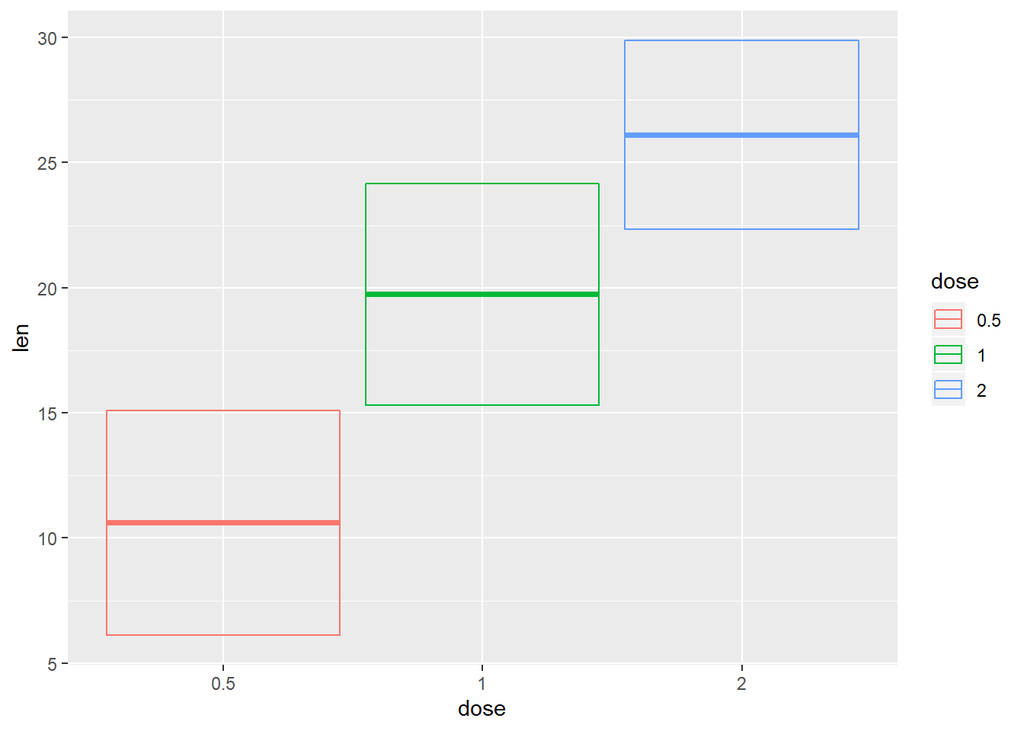

```r
f+geom_crossbar(aes(color=dose))
```

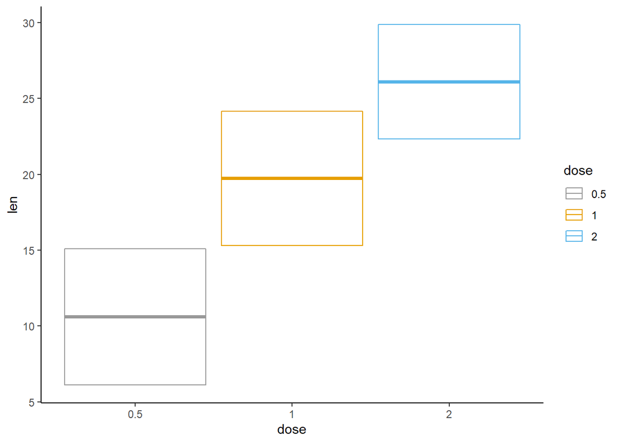

```r
f+geom_crossbar(aes(color=dose))+
  scale_color_manual(values = c("#999999", "#E69F00", "#56B4E9"))+theme_classic()
```

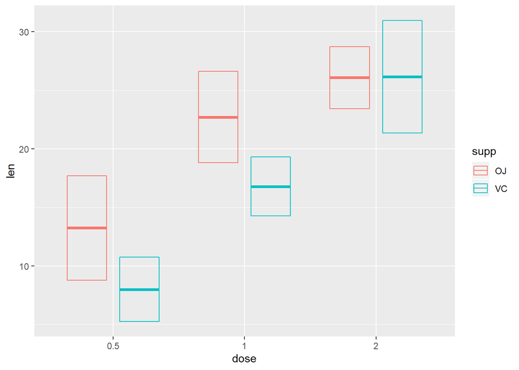

```r
f <- ggplot(df, aes(x=dose, y=len, color=supp))
f+stat_summary(fun.data = mean_sdl, fun.args = list(mult=1), geom="crossbar", width=0.6, position = position_dodge(0.8))
```

as factor再次确认一次 数字变成factor不可以加减，而是分类不再是0.5+0.5=1，而是二因为是两种分类 要编一个函数 gata_summary对象名,function 是运作, data_summary <- function(data, varname, grps){ require(plyr) ddply(data, grps, .fun=summary_func, varname)是循环 ymin就是标准差 f+geom_crossbar()空心树，这只是展示方式 scale自定义

透明的scalebrewer颜色的排序，红橙黄绿，gradient渐变

scaler颜色的梯度 scale fill实心颜色 linetype cont线性

errorbar标准差

```r
library(ggplot2)
library(maps)
head(USArrests)
```

```
##            Murder Assault UrbanPop Rape
## Alabama      13.2     236       58 21.2
## Alaska       10.0     263       48 44.5
## Arizona       8.1     294       80 31.0
## Arkansas      8.8     190       50 19.5
## California    9.0     276       91 40.6
## Colorado      7.9     204       78 38.7
```

```r
crimes <- data.frame(state=tolower(rownames(USArrests)), USArrests)
head(crimes)
```

```
##                 state Murder Assault UrbanPop Rape
## Alabama       alabama   13.2     236       58 21.2
## Alaska         alaska   10.0     263       48 44.5
## Arizona       arizona    8.1     294       80 31.0
## Arkansas     arkansas    8.8     190       50 19.5
## California california    9.0     276       91 40.6
## Colorado     colorado    7.9     204       78 38.7
```

```r
library(reshape2)
crimesm <- melt(crimes, id=1)
head(crimesm)
```

```
##        state variable value
## 1    alabama   Murder  13.2
## 2     alaska   Murder  10.0
## 3    arizona   Murder   8.1
## 4   arkansas   Murder   8.8
## 5 california   Murder   9.0
## 6   colorado   Murder   7.9
```

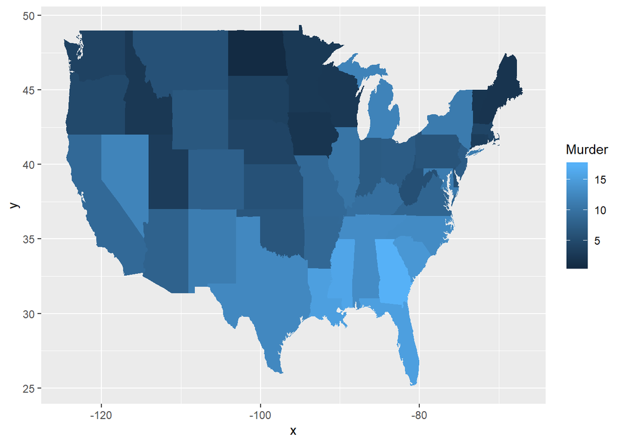

```r
map_data <- map_data("state")
#绘制地图，使用Murder进行着色
ggplot(crimes, aes(map_id=state))+
  geom_map(aes(fill=Murder), map=map_data)+
  expand_limits(x=map_data$long, y=map_data$lat)
```

reshape2数据转换，melt多页变两页

```r
library(ggplot2)
df <- data.frame(dose=c("D0.5", "D1", "D2"),
                len=c(4.2, 10, 29.5))
head(df)
```

```
##   dose  len
## 1 D0.5  4.2
## 2   D1 10.0
## 3   D2 29.5
```

```r
df <- data.frame(supp=rep(c("VC", "OJ"), each=3),
                dose=rep(c("D0.5", "D1", "D2"),2),
                len=c(6.8, 15, 33, 4.2, 10, 29.5))
head(df)
```

```
##   supp dose  len
## 1   VC D0.5  6.8
## 2   VC   D1 15.0
## 3   VC   D2 33.0
## 4   OJ D0.5  4.2
## 5   OJ   D1 10.0
## 6   OJ   D2 29.5
```

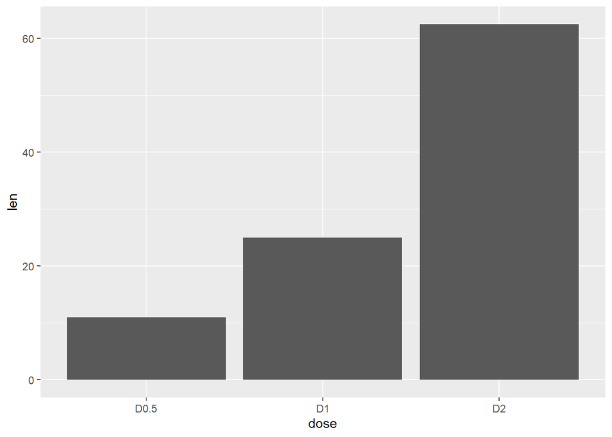

```r
f <- ggplot(df, aes(x = dose, y = len))
f + geom_bar(stat = "identity")
```

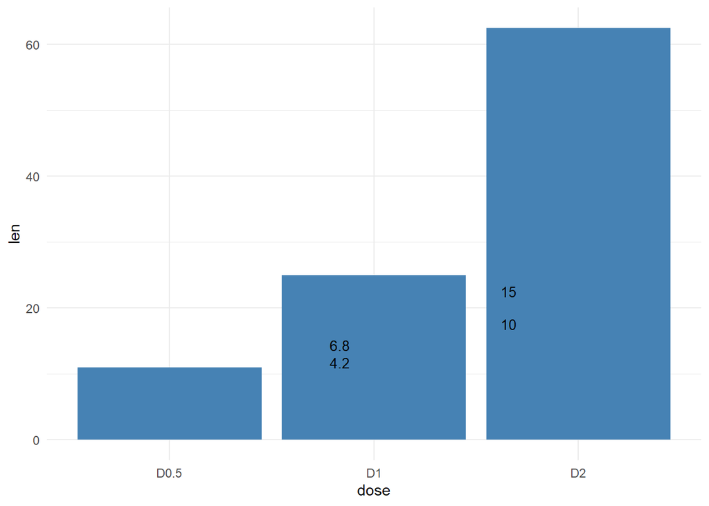

```r
f + geom_bar(stat="identity",fill="steelblue")+geom_text(aes(label=len),vjust=-4, hjust=-8,size=3.5)+theme_minimal()
```

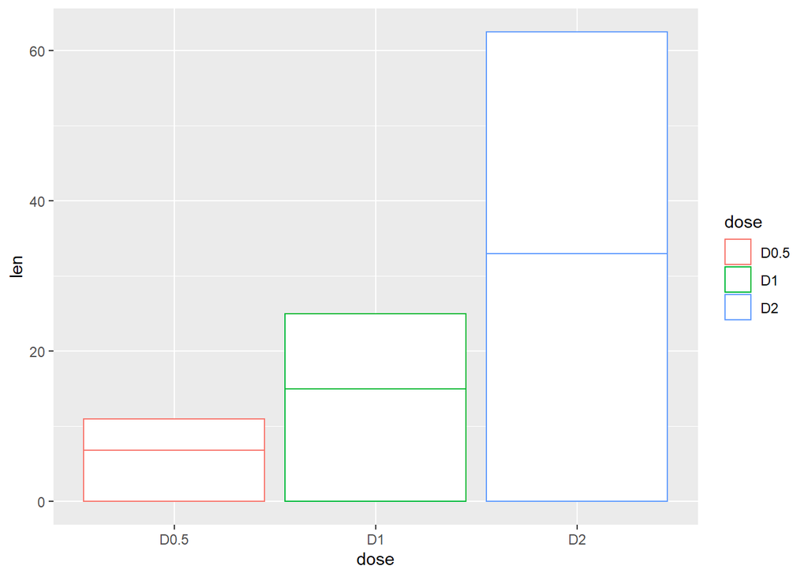

```r
f + geom_bar(aes(color = dose),
             stat="identity", fill="white")
```

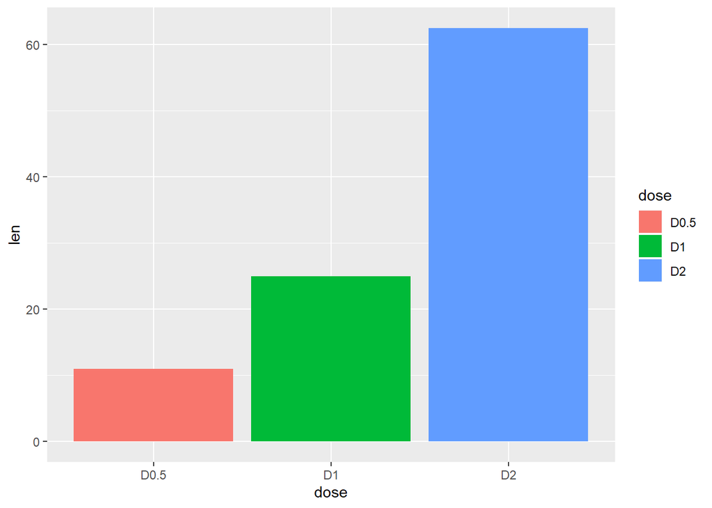

```r
f + geom_bar(aes(fill = dose), stat="identity")
```

vjust垂直调整，负的是向上 hjust负是向右

```r
library(ggplot2)
df <- data.frame(supp=rep(c("VC", "OJ"), each=3),
                dose=rep(c("D0.5", "D1", "D2"),2),
                len=c(6.8, 15, 33, 4.2, 10, 29.5))
head(df)
```

```
##   supp dose  len
## 1   VC D0.5  6.8
## 2   VC   D1 15.0
## 3   VC   D2 33.0
## 4   OJ D0.5  4.2
## 5   OJ   D1 10.0
## 6   OJ   D2 29.5
```

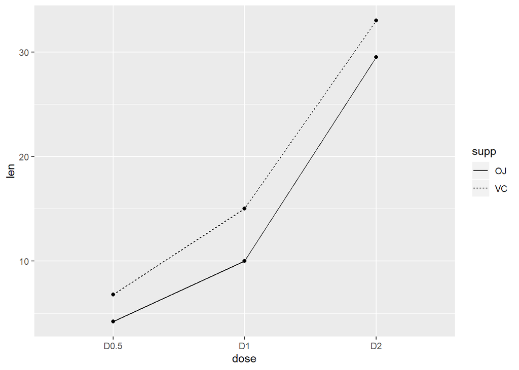

```r
ggplot(df, aes(x=dose, y=len, group=supp)) +
  geom_line(aes(linetype=supp))+
  geom_point()
```

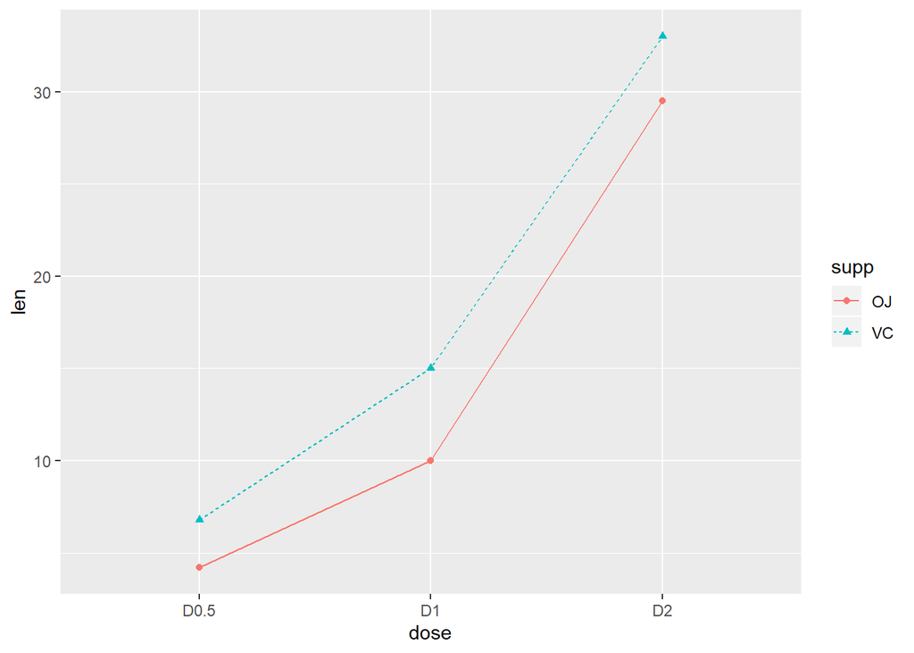

```r
ggplot(df, aes(x=dose, y=len, group=supp)) +geom_line(aes(linetype=supp, color = supp))+geom_point(aes(shape=supp, color = supp))
```

geom_point(color=“red”)

geom_point(aes(shape=supp, color = supp))可以因子分类统计

```r
library(ggplot2)
ToothGrowth$dose <- as.factor(ToothGrowth$dose)
head(ToothGrowth)
```

```
##    len supp dose
## 1  4.2   VC  0.5
## 2 11.5   VC  0.5
## 3  7.3   VC  0.5
## 4  5.8   VC  0.5
## 5  6.4   VC  0.5
## 6 10.0   VC  0.5
```

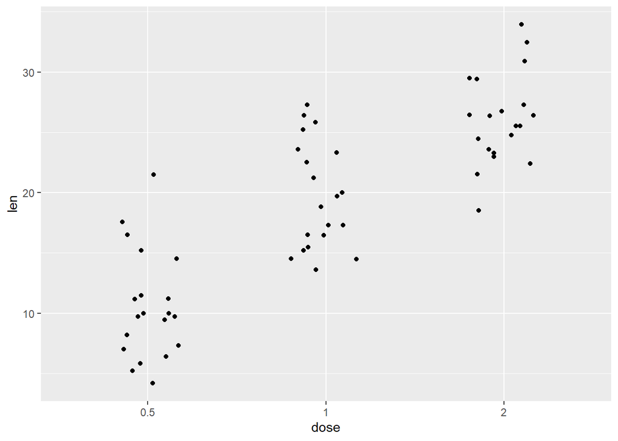

```r
e <- ggplot(data = ToothGrowth, aes(x=dose, y=len))
e + geom_jitter(position=position_jitter(0.2))
```

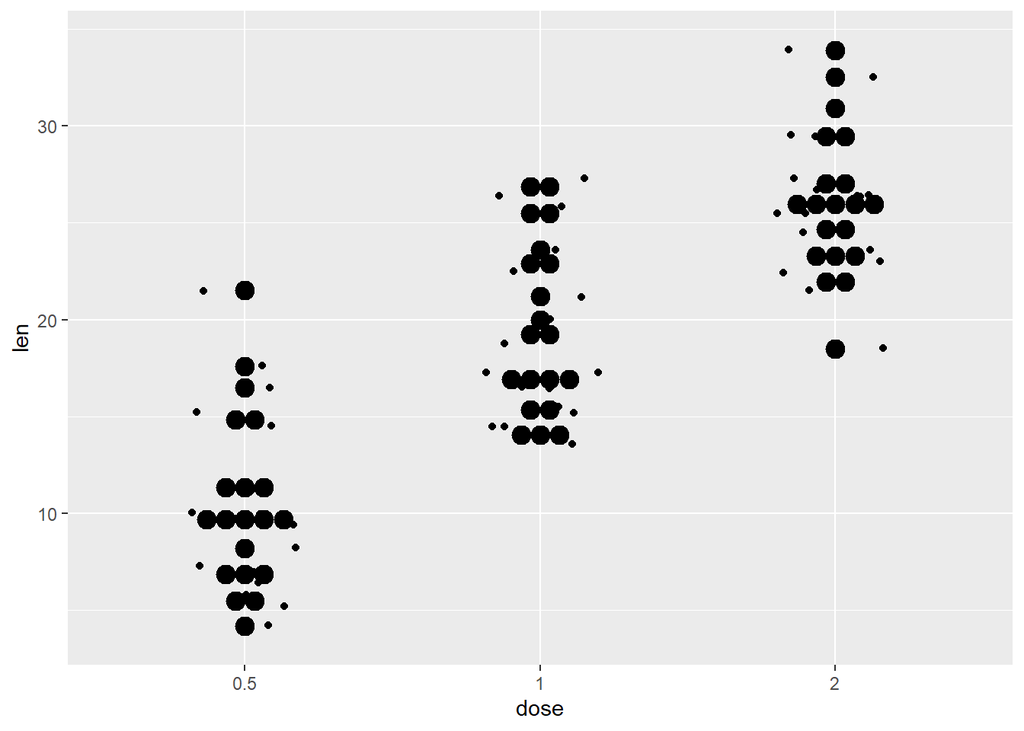

```r
e + geom_jitter(position=position_jitter(0.2)) +
  geom_dotplot(binaxis = "y", stackdir = "center")
```

```r
ToothGrowth$dose <- as.factor(ToothGrowth$dose)
head(ToothGrowth)
```

```
##    len supp dose
## 1  4.2   VC  0.5
## 2 11.5   VC  0.5
## 3  7.3   VC  0.5
## 4  5.8   VC  0.5
## 5  6.4   VC  0.5
## 6 10.0   VC  0.5
```

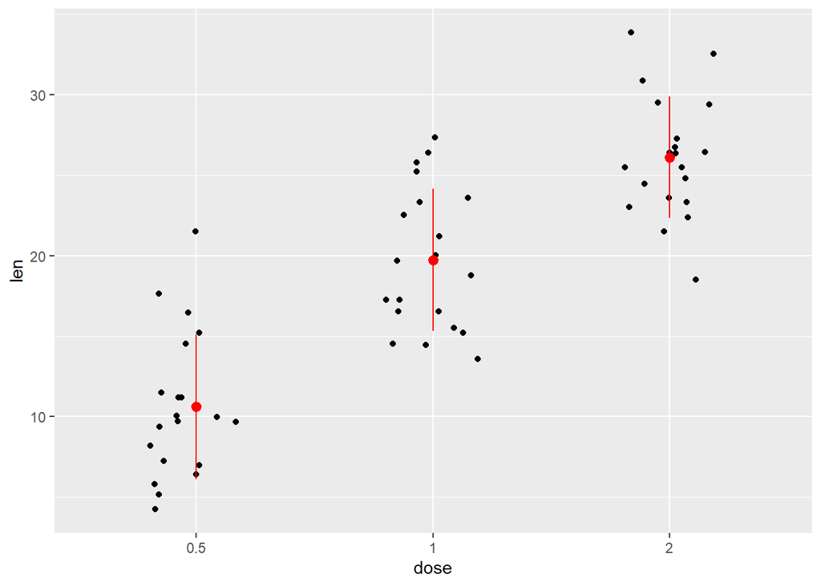

```r
f <-ggplot(data = ToothGrowth, aes(x=dose, y=len))
f + geom_jitter(position=position_jitter(0.2)) + stat_summary(fun.data="mean_sdl",  fun.args =list(mult=1),geom="pointrange", color = "red")
```

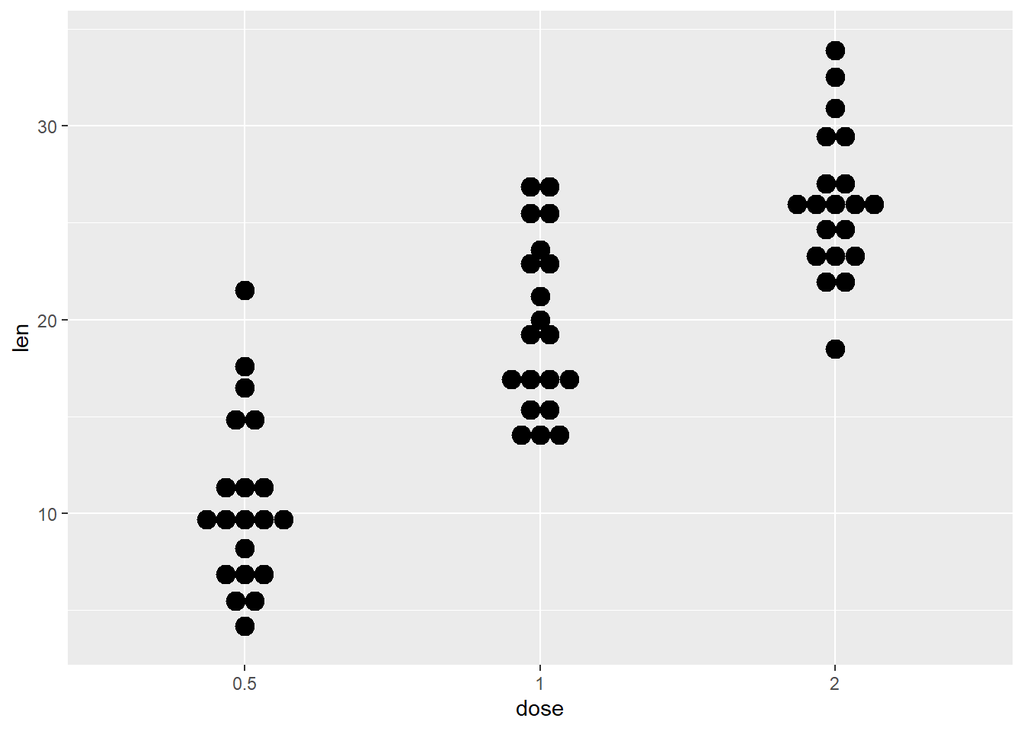

```r
f + geom_dotplot(binaxis = "y", stackdir = "center")
```

rep重复三次

```r
library(ggplot2)
df <- data.frame(supp=rep(c("VC", "OJ"), each=3),
                dose=rep(c("D0.5", "D1", "D2"),2),
                len=c(6.8, 15, 33, 4.2, 10, 29.5))
head(df)
```

```
##   supp dose  len
## 1   VC D0.5  6.8
## 2   VC   D1 15.0
## 3   VC   D2 33.0
## 4   OJ D0.5  4.2
## 5   OJ   D1 10.0
## 6   OJ   D2 29.5
```

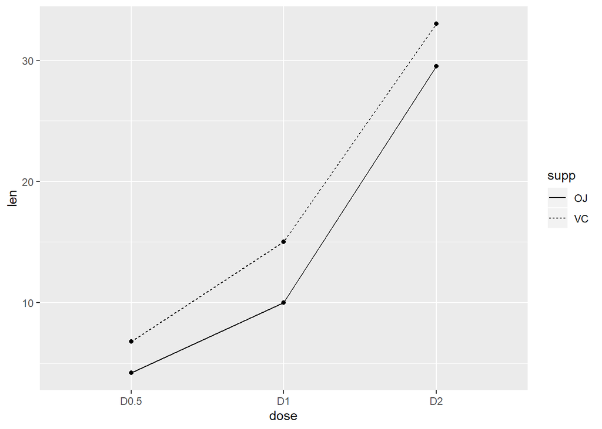

```r
ggplot(df, aes(x=dose, y=len, group=supp)) +
  geom_line(aes(linetype=supp))+
  geom_point()
```

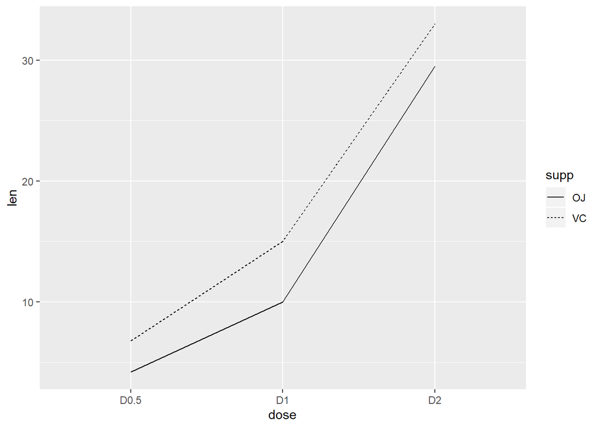

```r
library(ggplot2)
f <-ggplot(df, aes(x=dose, y=len, group=supp))
f+geom_line(aes(linetype=supp))
```

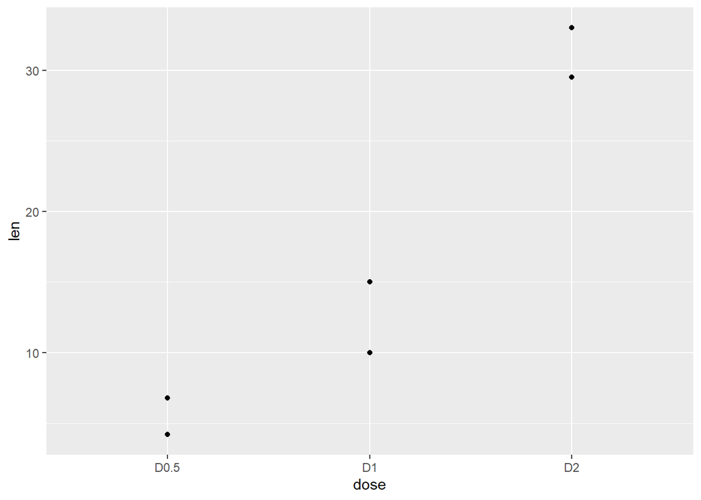

```r
f+ geom_point()
```

linetype=supp给线分类